# Effectives of Vaccines

Vaccines have helped save millions of lives. In the 19th century, before herd immunization was achieved through vaccination programs, deaths from infectious diseases, like smallpox and polio, were common. However, today, despite all the scientific evidence for their importance, vaccination programs have become somewhat controversial.

The controversy began with a paper published in 1988 by [Andrew Wakefield](https://en.wikipedia.org/wiki/Andrew_Wakefield) claiming there was a link between the administration of the measles, mumps and rubella (MMR) vaccine, and the appearance of autism. Despite further research contradicting this finding, sensationalist media reports and fear mongering from conspiracy theorists have led parts of the public to believe that vaccines are harmful. Some parents have stopped vaccinating their children, and this dangerous practice can be potentially disastrous given that the Center for Disease Control (CDC) estimates that vaccinations will prevent more than 21 million hospitalizations and 732,000 deaths among children born in the last 20 years (see [Benefits from Immunization during the Vaccines for Children Program Era — United States, 1994-2013, MMWR](https://www.cdc.gov/mmwr/preview/mmwrhtml/mm6316a4.htm)).

Effective communication of data is a strong antidote to misinformation and fear mongering. We are going to prepare a report to show the positive impact vaccines have had for public health.

The data used for these plots were collected, organized and distributed by the [Tycho Project](http://www.tycho.pitt.edu/). The data from this project are compiled neatly in the `dslabs` package:

```r
library(dslabs)
data(us_contagious_diseases)
head(us_contagious_diseases)
```

```
##       disease   state year weeks_reporting count population
## 1 Hepatitis A Alabama 1966              50   321    3345787
## 2 Hepatitis A Alabama 1967              49   291    3364130
## 3 Hepatitis A Alabama 1968              52   314    3386068
## 4 Hepatitis A Alabama 1969              49   380    3412450
## 5 Hepatitis A Alabama 1970              51   413    3444165
## 6 Hepatitis A Alabama 1971              51   378    3481798
```

To get us started, we will use the `us_contagious_disease` dataframe and `dplyr` tools to create an object called `measles_data` that stores only the Measles data. Then, we will create a per 100,000 people cumulative incidence rate. We will also remove Alaska and Hawaii since they only became states in the late 50s. We will take into account the `weeks_reporting` column when computing the per 100,000 people measles rate.

```r
library(dplyr)
dat <- us_contagious_diseases %>% filter(disease == "Measles" & !(state %in% c("Alaska", "Hawaii"))) %>%
  mutate(measles_rate = (count / population * 100000) / (weeks_reporting/52))
head(dat)
```

```
##   disease   state year weeks_reporting count population measles_rate
## 1 Measles Alabama 1928              52  8843    2589923    341.43872
## 2 Measles Alabama 1929              49  2959    2619131    119.89333
## 3 Measles Alabama 1930              52  4156    2646248    157.05255
## 4 Measles Alabama 1931              49  8934    2670818    354.98411
## 5 Measles Alabama 1932              41   270    2693027     12.71577
## 6 Measles Alabama 1933              51  1735    2713243     65.19945
```

Next, let’s take a look at just one state. I will plot the Measles disease rate per year for the state of Massachusetts. According to the [CDC](https://www.cdc.gov/measles/about/history.html), the first Measles vaccine was introduced in 1963 by John Enders and colleagues. I will add a vertical line to the plot to show this year.

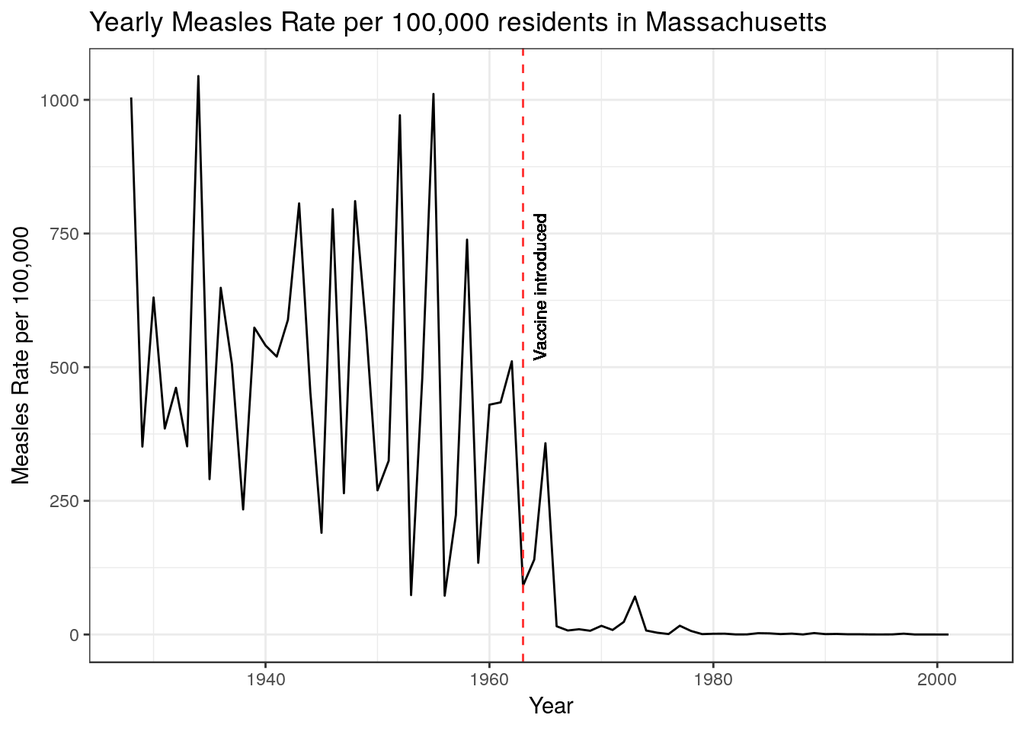

```r
library(ggplot2)
theme_set(theme_bw())

dat %>% filter(state == "Massachusetts") %>%
  ggplot(aes(x=year, y=measles_rate)) +
  geom_line(na.rm = T) +
  geom_vline(xintercept=1963, color="firebrick1", lty=2) +
  geom_text(aes(x=1964.5, label="Vaccine introduced", y=650), angle=90, size=3) +
  labs(title="Yearly Measles Rate per 100,000 residents in Massachusetts", y="Measles Rate per 100,000", x="Year")
```

As we can see above, it appears that after the introduction of the measles vaccine in 1963, the measles rate begins to drop drastically and stabilize around 0. However, this is just Massachusetts. Does the pattern hold for other states? Let’s use boxplots to get an idea of the distribution of rates for each year, and see if the pattern holds across states.

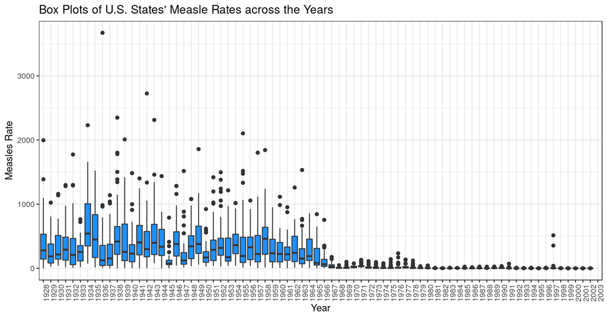

```r
dat %>% ggplot(aes(factor(year), measles_rate)) +
  geom_boxplot(na.rm = T, fill="dodgerblue") +
  theme(axis.text.x = element_text(angle = 90, hjust = 1)) +
  labs(title="Box Plots of U.S. States' Measle Rates across the Years", y="Measles Rate", x="Year")
```

As we can see, over the years, the distribution of measles rates tends to become less variable across the states and all of the measle rates in each of the states appear to decrease drastically after the introduction of the measles vaccine in 1963. However, one problem with the boxplot is that it does not let us see state-specific trends. Let’s make a plot showing the trends for all states, including the U.S. average.

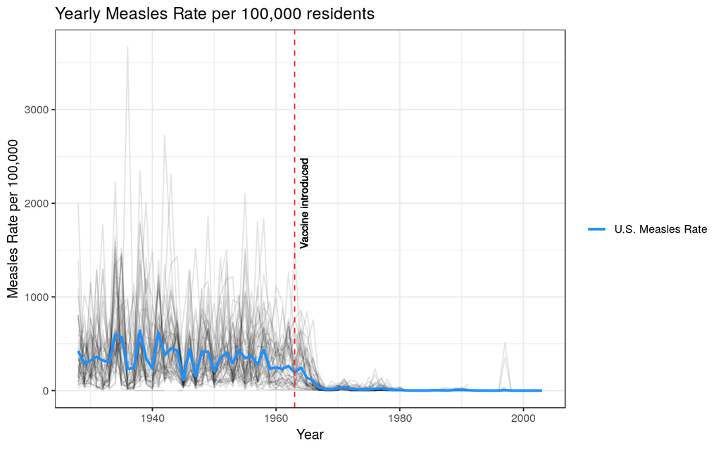

```r
dat <- dat %>% mutate(count_reporting = (52/weeks_reporting) * count)
national_rate <- dat %>% group_by(year) %>% summarize(rate = sum(count_reporting, na.rm = T) / sum(population, na.rm = T) * 100000)

dat %>% ggplot(aes(x=year, y=measles_rate)) +
  geom_line(aes(group = state), na.rm = T, alpha=0.1) +
  geom_line(data = national_rate, aes(y=rate, color="U.S. Measles Rate"), na.rm = T, size = 1) +
  geom_vline(xintercept=1963,lty=2, color = "firebrick1") +
  geom_text(aes(x=1964.5, label="Vaccine introduced", y=2000), angle=90, size=3) +
  labs(title="Yearly Measles Rate per 100,000 residents", y="Measles Rate per 100,000", x="Year") +
  scale_colour_manual("", values = c("dodgerblue"))
```

Again we can see that the all the states, and the U.S. as a whole, appear to follow the same trend. However, one problem with the plot above is that we can’t distinguish states from each other. There are just too many. We have three variables to show: year, state and rate. If we use the two dimensions to show year and state then we need something other than vertical or horizontal position to show the rates. Let’s try using color. Note that we will be using a square root transformation of the heat map to make the plot more interpretable.

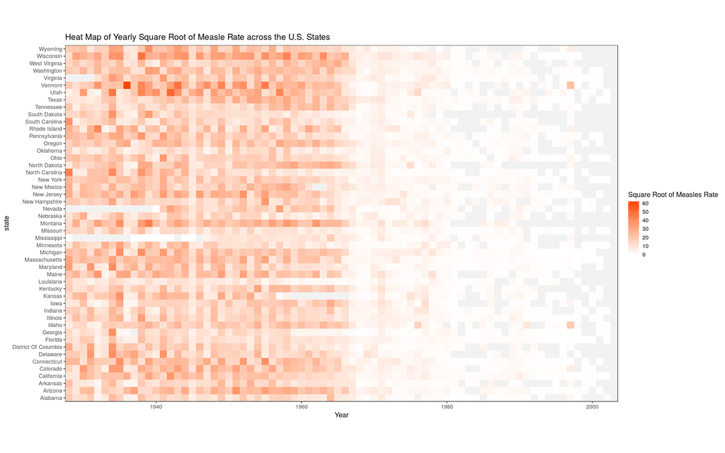

```r
ggplot(data = dat, aes(x=year, y=state)) +
  geom_tile(aes(fill=sqrt(measles_rate))) +
  coord_equal() +
  scale_x_continuous(expand=c(0,0)) +
  scale_y_discrete(expand=c(0,0)) +
  scale_fill_continuous("Square Root of Measles Rate", low = "white", high = "orangered", na.value = "gray95") +
  labs(title="Heat Map of Yearly Square Root of Measle Rate across the U.S. States", x="Year", Y="State")
```

Al of these plots above provide strong evidence showing the benefits of vaccines: as vaccines were introduced, disease rates were reduced. But did autism increase? We find some yearly reported autism rates data and provide a plot that shows if it has increased and if the increase coincides with the introduction of vaccines.

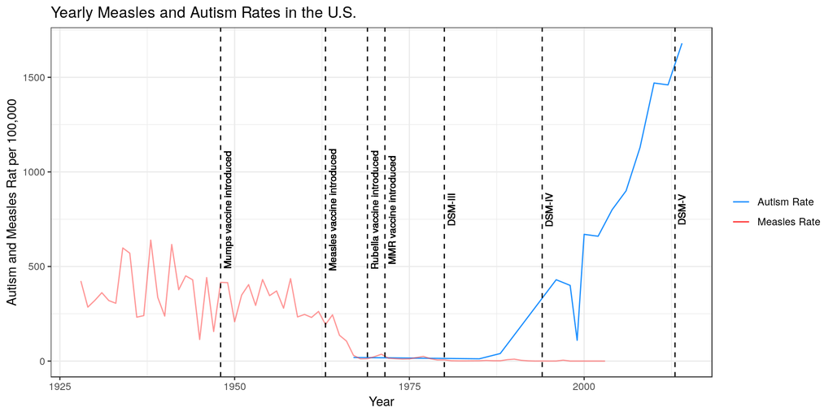

```r
# autism data taken from CDC (https://www.cdc.gov/ncbddd/autism/documents/ASDPrevalenceDataTable2016.pdf)
# prevalence is given as per 1,000 children
us_years <- c(1967, 1985, 1988, 1996, 1998, 1999, 2000, 2002, 2004, 2006, 2008, 2010, 2012, 2014)
autism_prevalence <- c(0.19, 0.12, 0.4, 4.3, 4.0, 1.1, 6.7, 6.6, 8.0, 9.0, 11.3, 14.7, 14.6, 16.8)

autism_df <- data.frame(year = us_years, prevalence = autism_prevalence)

ggplot(data=autism_df, aes(x=year, y=prevalence * 100)) +
  geom_line(aes(color = "Autism Rate")) +
  geom_line(data=national_rate, aes(x=year, y=rate, color="Measles Rate"), na.rm = T, alpha = 0.5) +
  geom_vline(xintercept=1948,lty=2) +
  geom_text(aes(x=1949, label="Mumps vaccine introduced", y=800), angle=90, size=3) +
  geom_vline(xintercept=1963,lty=2) +
  geom_text(aes(x=1964, label="Measles vaccine introduced", y=800), angle=90, size=3) +
  geom_vline(xintercept=1969,lty=2) +
  geom_text(aes(x=1970, label="Rubella vaccine introduced", y=800), angle=90, size=3) +
  geom_vline(xintercept=1971.5,lty=2) +
  geom_text(aes(x=1972.5, label="MMR vaccine introduced", y=800), angle=90, size=3) +
  geom_vline(xintercept=1980,lty=2) +
  geom_text(aes(x=1981, label="DSM-III", y=800), angle=90, size=3) +
  geom_vline(xintercept=1994,lty=2) +
  geom_text(aes(x=1995, label="DSM-IV", y=800), angle=90, size=3) +
  geom_vline(xintercept=2013,lty=2) +
  geom_text(aes(x=2014, label="DSM-V", y=800), angle=90, size=3) +
  labs(title="Yearly Measles and Autism Rates in the U.S.", x="Year", y="Autism and Measles Rat per 100,000") +
  scale_colour_manual("", values = c("dodgerblue", "firebrick1"))
```